# Tarea 1

El siguiente comando de R permite cargar un archivo de datos en formato CSV.

```r
data <- read.csv("jobs_in_data.csv")
```

Utilizado como referencia el archivo de datos con información de personas que trabajan en [Ciencias de Datos](https://www.kaggle.com/datasets/hummaamqaasim/jobs-in-data), genere las gráficas que se muestran a continuación (debe mostrar todo el código R necesario para generarlas). Note que puede ser necesario investigar algunas opciones de *ggplot* para mejorar la apariencia de la gráfica (por ejemplo, etiquetas).

### 1. Distribución de salario anual por categoría de trabajo

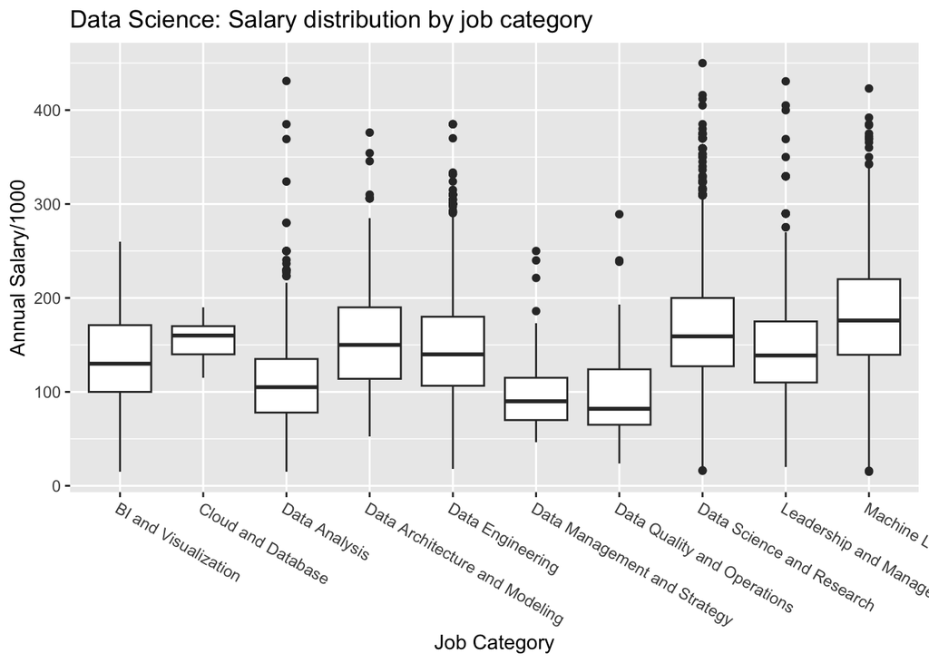

A partir de la gráfica anterior responda las siguientes preguntas:

- A. Cuál es la categoría de trabajo donde el salario es más uniforme ? Explique porqué.
- B. Cúal es la categoría de trabajo donde el salario varía más ? Explique porqué.
- C. Cúal es la categoría de trabajo en donde se gana más salario en promedio ? Explique porqué.
- D. Cuál es la categoría de trabajo en donde se gana menos salario en promedio ? Explique porqué.

### 2. Cantidad de trabajos por categoría

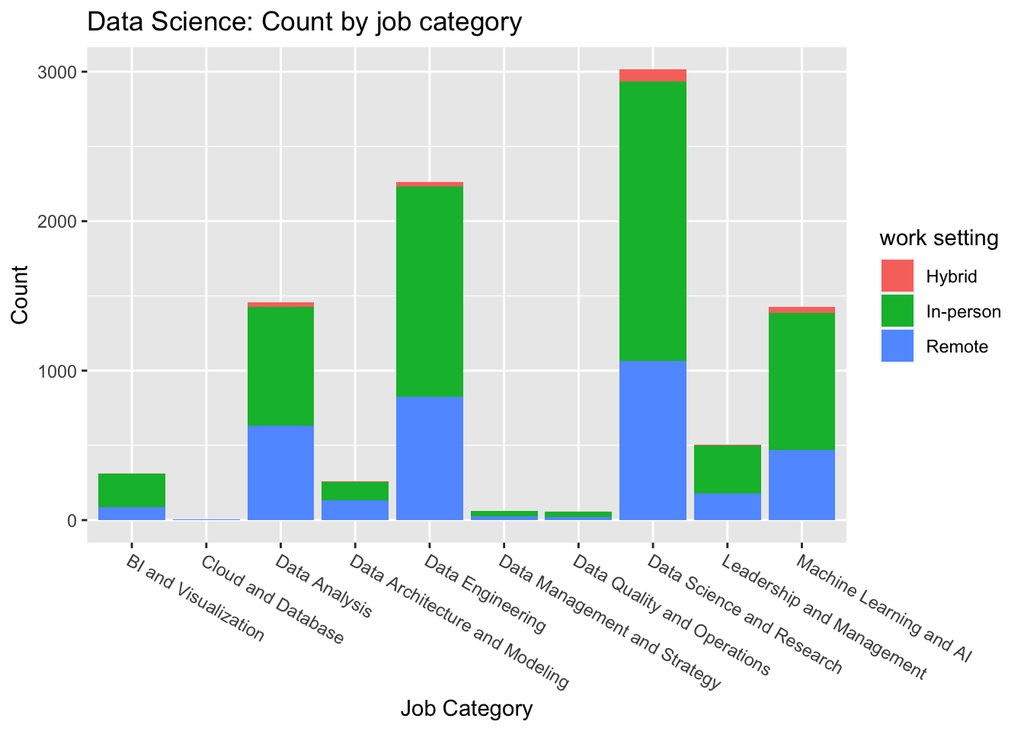

A partir de la gráficas anteriores responda las siguientes preguntas:

- A. Cuál es la categoría de trabajo donde existe mayor cantidad de puestos y es mejor pagado ? Explique porqué.
- B. Cúal es la categoría de trabajo donde existe un buen salario pero hay pocos puestos disponibles ? Explique porqué.
- C. Cúal es la categoría de trabajo peor pagado y con menor cantidad de puestos disponibles ? Explique porqué.
- D. Cuál es la categoría de trabajo con mayor cantidad de puestos pero salarios bajos ? Explique porqué.

### 3. Salarios por nivel de experiencia

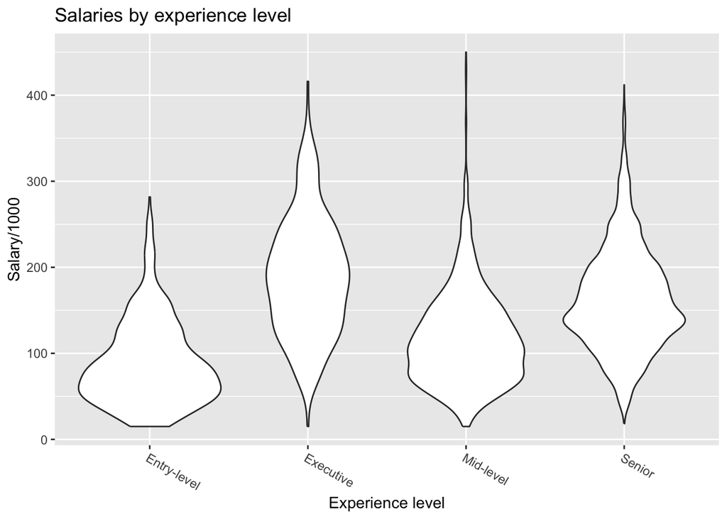

A partir de la gráficas anteriores responda las siguientes preguntas:

- A. En promedio cúal es el nivel de experiencia con los peores salarios ? Explique porqué.
- B. En promedio cuál es el nivel de experiencia con los mejores salarios ? Explique porqué.
- C. Cuál es el nivel de experiencia que tiene el salario más alto ? Explique porqué.
- D. Cuál es el nivel de experiencia que tiene un rango de salarios más amplio ? Explique porqué.

### 4. Cantidad de puestos por nivel de experiencia y año

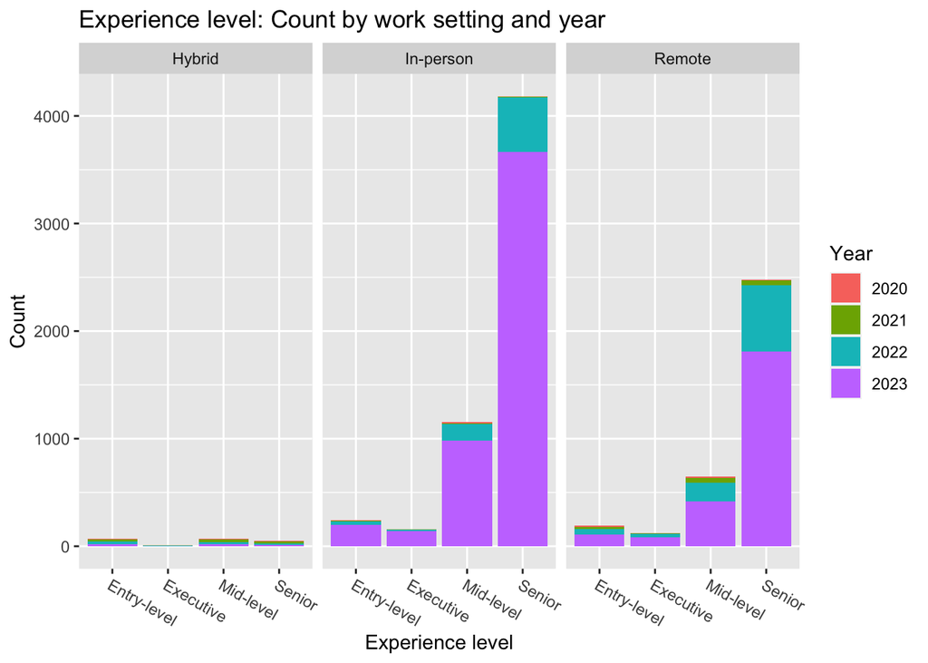

A partir de la gráficas anteriores responda las siguientes preguntas:

- A. Cuál es el año donde más se crearon trabajos remotos para personas con nivel senior? Explique porqué.
- B. Qué nivel de experiencia tenía más posibilidad de obtener un puesto remoto en el 2023? Explique porqué.
- C. Para cúal nivel de experience se crearon, a través de los años, una mayor proporción de trabajos ? Explique porqué.
- D. Cuál fue el año que solo se ofrecieron trabajos presenciales para ejecutivos ? Explique porqué.